# Data wrangling 2

Ben Whalley

November 2021

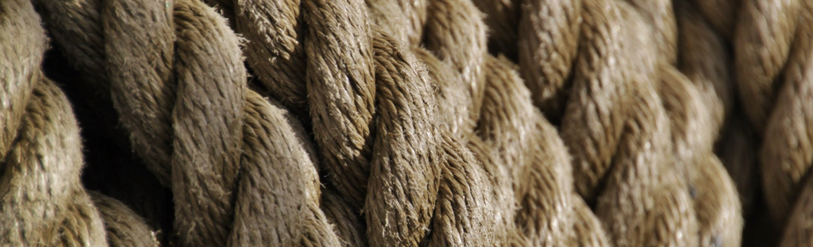

# Overview

In this session we cover 3 additional, common tasks when tidying up real data-sets:

1. Recoding data (e.g. questionnaire responses) from text to numeric values
2. Separating ‘untidy’ columns into tidy, long-form data:
3. Joining two sources of data (e.g. two spreadsheets) into a single dataframe

# Separating variables

Sometimes we need to separate ‘untidy’ variables into tidy, long-form data.

[video not shown]

The code below generates simulated data for 100 individuals at three time points. The format is similar to the way you might record experimental data in a spreadsheet.

```r
N <- 100
repeatmeasuresdata <- tibble(person = 1:N,
                              time_1 = rnorm(N),
                              time_2 = rnorm(N, 1),
                              time_3 = rnorm(N, 3))

repeatmeasuresdata %>% head(8)
```

```
# A tibble: 8 × 4
  person  time_1 time_2 time_3
   <int>   <dbl>  <dbl>  <dbl>
1      1  1.78    1.29   4.11
2      2 -0.595   0.984  3.05
3      3  2.05    1.79   0.372
4      4 -1.77    1.55   3.13
5      5 -0.0585  1.14   3.22
6      6 -1.05    0.984  3.06
7      7 -0.674   0.387  3.10
8      8 -1.68    1.81   2.84
```

This variable, `repeatmeasuresdata`, is in **wide** format. Each row contains data for one participant, and each participant has three observations.

As we saw previously, we can *pivot* — i.e., reshape — the data into longer format like so:

```r
repeatmeasuresdata %>%
  pivot_longer(starts_with("time")) %>%
  arrange(person, name) %>%
  head(8)
```

```
# A tibble: 8 × 3
  person name    value
   <int> <chr>   <dbl>
1      1 time_1  1.78
2      1 time_2  1.29
3      1 time_3  4.11
4      2 time_1 -0.595
5      2 time_2  0.984
6      2 time_3  3.05
7      3 time_1  2.05
8      3 time_2  1.79
```

The problem we have now is that `name` contains text which describes at which time the observation was made. We probably want to store a *number* for each time-point, so we can make a plot with time on the x axis.

The `separate` command separates a single character column (`name`) into multiple columns. Rather than have a column with labels of the form ‘time_1’, it can create two columns, with labels ‘time’ and ‘1’ in each.

```r
# convert to long form; extract the `time` as a new numeric column
longrepeatmeasuresdata <- repeatmeasuresdata %>%
  pivot_longer(starts_with("time")) %>%
  separate(name, into = c("variable", "time"))

longrepeatmeasuresdata %>% head
```

```
# A tibble: 6 × 4
  person variable time   value
   <int> <chr>    <chr>  <dbl>
1      1 time     1      1.78
2      1 time     2      1.29
3      1 time     3      4.11
4      2 time     1     -0.595
5      2 time     2      0.984
6      2 time     3      3.05
```

Now the data are in long format, we can plot the points over time:

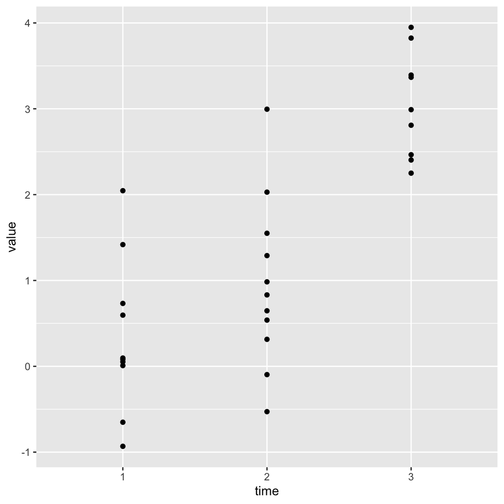

```r
longrepeatmeasuresdata %>%
  sample_n(30) %>%
  ggplot(aes(x=time, y=value)) +
  geom_point()
```

### How does R know where to split the text?

In the example above, `separate` split data like `"time_1"`, `"time_2"` etc into two columns: `variable` and `time`.

Q: How did it know to use the underscore (`_`) to split the data?

A: The default is to split on anything which is not a letter or number. So `_` or a space, or `,` would all work.

Sometimes though we need to tell R explicitly what to use to sepatate the values.

If we had a column of email addresses we could split `ben.whalley@plymouth.ac.uk` into the username (e.g. `ben.whalley`) and domain name (`plymouth.ac.uk`) using the `@` symbol.

To do this we just write `sep="@"` when we use separate.

The `messy_exp` dataset in `psydata` contains simulated RT data on 100 participants in 2 conditions (A and B) at three time points (1, 2, and 3).

- Use the `separate()` function to split up the `condition` variable in this dataset and draw the following plot:

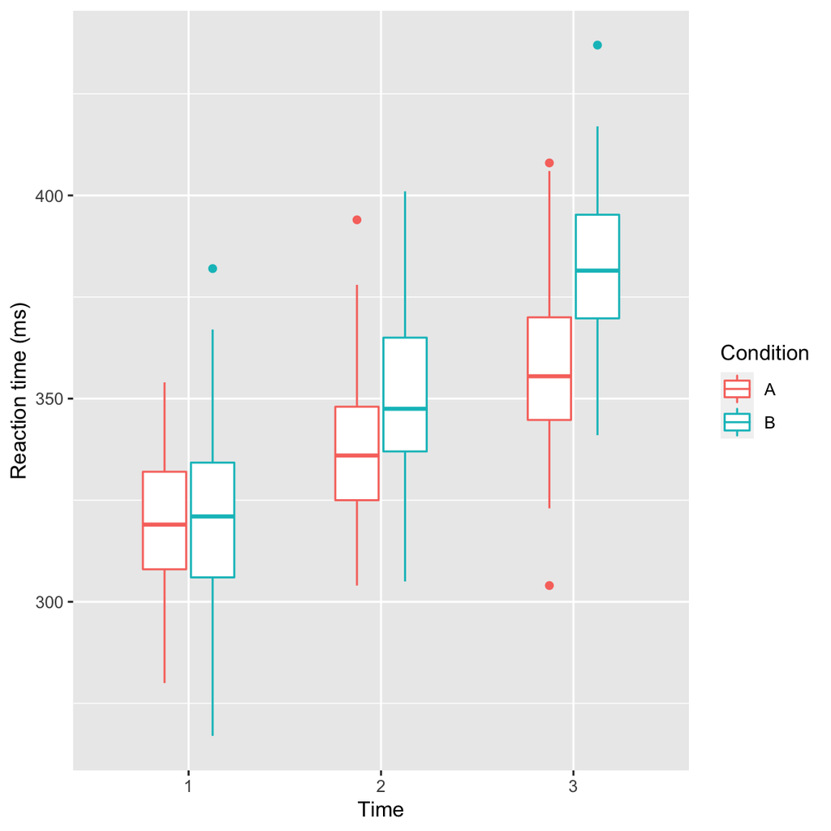

```r
messy_exp %>%
  separate(condition, into=c("participant", "condition", "time")) %>%
  ggplot(aes(time, rt, color=condition)) +
  geom_boxplot(width=.5) +
  labs(x="Time", y="Reaction time (ms)", color="Condition")
```

1. This file contains sample contact and address data for 100 people: https://letterhub.com/wp-content/uploads/2018/03/100-contacts.csv
- Read the data into R (you can either use the URL above directly inside the `read_csv()` function, or download then re-upload the data to the server to do this)
- Use the `separate` function to make a new variable which contains the *domain name* of these contacts’ email address (e.g. yahoo.com, hotmail.com)

> Note, you will need to use `sep="@"` to split the email addresses at the `@` symbol
2. Use the `distinct` and/or `count` functions on the new variable you create containing the domain name. Look them up in the help file if you don’t know which to use to answer these questions:
- How many people had a Gmail account?
- Which domains had more than 10 users?

```r
# read the data directly from the URL
contacts <- read_csv('https://letterhub.com/wp-content/uploads/2018/03/100-contacts.csv') %>%
  separate(email, into=c("user", "domain"), sep ="@")  # uses the @ symbol as a separator
```

```r
# how many _different_ domains are there?
contacts %>%
  distinct(domain) %>%
  count()
```

```
# A tibble: 1 × 1
      n
  <int>
1    39
```

```r
# how many people use gmail
contacts %>%
  count(domain) %>%
  filter(domain=="gmail.com")
```

```
# A tibble: 1 × 2
  domain        n
  <chr>     <int>
1 gmail.com    16
```

```r
# which domains had more than 10 users?
contacts %>%
  count(domain) %>%
  filter(n > 10)
```

```
# A tibble: 4 × 2
  domain          n
  <chr>       <int>
1 aol.com        13
2 gmail.com      16
3 hotmail.com    13
4 yahoo.com      13
```

# Questionnaire data

## Importing from Excel

You should always keep your data in csv format. Don’t use Excel or other proprietary formats to store data unless absolutely necessary.

Unfortunately, some tools (including Office 365 Forms) provide data in `xlsx` format, and for this we need to use a special function in R. You can import this data to RStudio by:

- Uploading the `xlsx` file to the RStudio server
- Make sure the uploaded file is in the same directory as your Rmd file
- Loading the `rio` package
- Using the `import()` function in that package, instead of `read_csv()`

The example data linked below were exported from an Office 365 Form, so they are in a similar format to that which you might expect using other online survey tools.

- **Download 'sweets' example in xslx format (`sweets.xlsx`)**

We can look at the first few rows of the data, using the `head` command:

```r
sweets %>% head()
```

```
  ID          Start time     Completion time     Email Name
1  6 2019-05-24 09:12:31 2019-05-24 09:12:35 anonymous   NA
2  7 2019-05-24 09:12:31 2019-05-24 09:12:35 anonymous   NA
3  8 2019-05-24 09:12:31 2019-05-24 09:12:35 anonymous   NA
4  9 2019-05-24 09:12:31 2019-05-24 09:12:35 anonymous   NA
  How much do you like sweets? How much do you like chocolate Gender
1            I don't like them              I don't like them      M
2                  I'm neutral              I don't like them      F
3                  I like them                    I'm neutral      M
4                  I'm neutral                    I'm neutral      F
```

[video not shown]

- Import the sweets data into RStudio, as shown above
- Save it to a new variable called `sweets`

## Tidying questionnaires

When we look at the imported data it’s useful to note:

1. There are extra columns we don’t need (at least for now).
2. Some of our variable names are very long and annoying to type (for example `How much do you like sweets?` is the name of one of our columns).
3. Our responses are in **text** format, rather than as numbers. For example, the data say `"I don't like them"` or `"I'm neutral"` rather than numbers from a 1-5 scale.
4. We may have other data on the same participants that are stored in separate files.

We need to sort each of these problems to make things more manageable for our analysis.

## Selecting and renaming

> Remember, R makes using columns with spaces or other special characters very hard. We want to avoid this.

### Selecting

To use columns with spaces in we must ‘escape’ the spaces and **let R know they are part of the name** rather than a gap between two different names.

This video shows how (or read below):

[video not shown]

To escape spaces and use columns with long names we use the backtick character (the backwards facing apostrophe) to *wrap* the column name.

**In general, if your columns contain spaces or other odd characters like hyphens or question marks then you will need to wrap them in backticks.**

### Renaming

Some of the imported variable names in the `sweets` data are long and awkward to use.

Most researchers would rename these variables, to make them more usable in R code.

You can rename variables like this:

```r
datasetname %>%
  rename(NEW_COLUMN_NAME = OLD_COLUMN_NAME)
```

So for this example:

```r
sweets %>%
  rename(
    like_sweets = `How much do you like sweets?`,
    like_chocolate = `How much do you like chocolate`,
  )
```

```
  ID          Start time     Completion time     Email Name       like_sweets
1  6 2019-05-24 09:12:31 2019-05-24 09:12:35 anonymous   NA I don't like them
2  7 2019-05-24 09:12:31 2019-05-24 09:12:35 anonymous   NA       I'm neutral
3  8 2019-05-24 09:12:31 2019-05-24 09:12:35 anonymous   NA       I like them
4  9 2019-05-24 09:12:31 2019-05-24 09:12:35 anonymous   NA       I'm neutral
     like_chocolate Gender
1 I don't like them      M
2 I don't like them      F
3       I'm neutral      M
4       I'm neutral      F
```

**Explanation of the code**: We used `rename` to change the names of our variables. We needed to wrap the long names of the questions in ‘backtick’ symbols to make sure R understood it was a single column name.

You should create a new variable to save the renamed dataset (with a descriptive name for use later on):

```r
# create a new variable containing the renamed dataset
sweets.renamed <- sweets %>%
  rename(
    like_sweets = `How much do you like sweets?`,
    like_chocolate = `How much do you like chocolate`,
  )
```

1. Create a copy of the sweets data in which you have selected only the two columns with long names.
2. Create a second copy of the data where you have renamed the columns with long names to something short, and without spaces.

### Renaming with the `janitor` package

A good alternative to renaming variables manually is to use the `clean_names` function in the `janitor` package.

```r
sweets %>%
  janitor::clean_names() %>%
  glimpse
```

```
Rows: 4
Columns: 8
$ id                             <dbl> 6, 7, 8, 9
$ start_time                     <dttm> 2019-05-24 09:12:31, 2019-05-24 09:12:3…
$ completion_time                <dttm> 2019-05-24 09:12:35, 2019-05-24 09:12:…
$ email                          <chr> "anonymous", "anonymous", "anonymous",…
$ name                           <lgl> NA, NA, NA, NA
$ how_much_do_you_like_sweets    <chr> "I don't like them", "I'm neutral", "I …
$ how_much_do_you_like_chocolate <chr> "I don't like them", "I don't like them…
$ gender                         <chr> "M", "F", "M", "F"
```

**Explanation of the code and result**. I used the `clean_names` function within the `janitor` package without using library. I did this by typing `janitor::` and then the name of the function. In the result `clean_names` has made a new dataset:

- Removed all special characters
- Made everything lower case (easier for R to autocomplete)
- Replaced spaces with underscores
- Made column names unique (this isn’t always the case with imported data, but is important for R)

I typically use this function when importing any new data because it makes the naming and access of columns much more consistent and easier to remember.

Repeat the previous exercise, but this time use `clean_names`.

# Recoding text

We noticed above that our responses were stored as text labels like `"I don't like them"` rather than on a numeric scale. This makes it hard to use in an analysis.

**We need to *recode* the text variables into numeric versions.**

### How to do it

First we must tell R what number we want to use for each text label. That is, we create a *mapping of numbers to labels*.

This takes a few steps:

1. Check **exactly** what the text values are which need to be mapped.
2. Make a **mapping variable** which assigns each text value a number value
3. Use the `recode` function with `mutate` to create a new, numeric column

This video walks you through the steps below:

[video not shown]

### Step 1: Check EXACTLY what text labels we have

To check which labels we need to recode, I select the column in question and use the `unique()` function.

```r
# check exactly what text values are in the dataset?
sweets %>%
  select(`How much do you like sweets?`) %>%
  unique()
```

```
  How much do you like sweets?
1            I don't like them
2                  I'm neutral
3                  I like them
```

Do the same to find out the possible values of the `How much do you like chocolate` column.

```r
sweets %>%
  select(`How much do you like chocolate`) %>%
  distinct()
```

```
  How much do you like chocolate
1              I don't like them
2                    I'm neutral
```

### Step 2: Make a mapping variable

We do this by creating what R calles a **named vector**, which is a special kind of list.

To make a named vector we use the the `c()` function. The letter `c` here just stands for ‘combine’ — i.e. ‘combine these things into a list’.

This is a simple example:

```r
mapping.list <- c("No" = 0, "Yes" = 1)
```

*A useful trick* when creating your own mappings is to use R to do the formatting for you (see the video above for a demo).

Re-using the code from the previous step, we use `unique()` to show us the *unique values* for the question about sweets.

We then pipe the result to the `paste()` and `cat()` functions, like this:

```r
# the hack we use as a short-cut to creating a mapping variable
sweets %>%
  select(`How much do you like sweets?`) %>%
  unique() %>%
  paste() %>% cat()
```

```
c("I don't like them", "I'm neutral", "I like them")
```

**Explanation of the output**: Using `paste` and `cat` is a bit of a hack. When we run this code we see the output `c("I don't like them", "I'm neutral", "I like them")`. This is a list of the values in the `sweets` data for this question, formatted in a way that will be useful to us in the next step.

We then copy and paste this output into a NEW code block, and EDIT it to assign our mappings:

```r
preference.mappings <- c("I don't like them" = -1, "I'm neutral" = 0, "I like them" = 1)
```

**Explanation of the code**: We used the previous output to create a mapping. By adding the parts which read `= -1` and `= 0` etc, we have told R what value we want to assign for each label.

Q: How do you know what number values to assign?

A: It doesn’t matter, provided:

- The intervals between each options are the same and
- Each text value has a different number

So, if we had a Likert-scale ranging from “Completely agree” to “Completely disagree” in 7 increments, we could score this from `0 - 6` or `1 - 7`, or `-3 - 3`. These would all be fine.

### Step 3: Use the mapping variable to recode the column

We can use our new mapping with the `mutate` and `recode` functions to make a **new column**, containing numbers rather than text:

```r
sweets.recoded <-  sweets %>%
    # use recode to convert text response using preference.mappings
    mutate(
        like_sweets_numeric =
            recode(`How much do you like sweets?`, !!!preference.mappings)
    )
```

We can see this new column if we use `glimpse`:

```r
sweets.recoded %>% glimpse()
```

```
Rows: 4
Columns: 9
$ ID                               <dbl> 6, 7, 8, 9
$ `Start time`                     <dttm> 2019-05-24 09:12:31, 2019-05-24 09:12…
$ `Completion time`                <dttm> 2019-05-24 09:12:35, 2019-05-24 09:1…
$ Email                            <chr> "anonymous", "anonymous", "anonymous…
$ Name                             <lgl> NA, NA, NA, NA
$ `How much do you like sweets?`   <chr> "I don't like them", "I'm neutral", "…
$ `How much do you like chocolate` <chr> "I don't like them", "I don't like th…
$ Gender                           <chr> "M", "F", "M", "F"
$ like_sweets_numeric              <dbl> -1, 0, 1, 0
```

**Explanation of the code**:

- The start of the first line is `sweets.recoded <-` which means make a new variable called `sweets.recoded`.
- Then we use `mutate` to create a **new** column called `like_sweets_numeric`.
- We make this column using `recode` on the question about liking sweets.
- We use the `preference.mappings` mapping to specify what numeric score to give each of the text values.

**Watch out for the exclamation marks`!!!`**: In the code above there are three exclamation marks, `!!!`, before the mapping; make sure you do the same.

### Three exclamation marks: `!!!`

Preface: Understanding this isn’t necessary to get on with the course. Only read this if you are interested!

In the code above when we used `recode` we used three exclamation marks just before our list.

We defined the mapping:

```r
likert.responses <- c(
            "I hate them" = 1,
            "I don't like them" = 2,
            "I'm neutral" = 3,
            "I like them" = 4,
            "I can't live without them" = 5)
```

And then used it with `recode`, with the three exclamation marks.

```r
liking_of_sweets_data %>%
    mutate(like_sweets_numeric = recode(like_sweets_text, !!!likert.responses))
```

The reason for this is that `recode` actually expects us to specify the mapping for it like this:

```r
liking_of_sweets_data %>%
    mutate(like_sweets_numeric = recode(like_sweets_text,
        "I hate them" = 1,
        "I don't like them" = 2 ...))
```

But this means we have to repeat the mapping for each of the questions. Because all the questions use the same mapping this gets repetitive, and can lead to errors.

The three exclamation marks `!!!` *unpacks* the list for us. So writing `!!!likert.responses` saves us the bother of writing it out in full each time.

### Summary/video explanation

This is one of the trickiest bits of R code we use. I’ve included an annotated video of just these steps as a reference below:

[video not shown]

- Use this three-step process to create a recoded version of the `like_chocolate` variable.
- Remember to watch the video at the start of this section, or the short version in the green box above, if anything is unclear.

# Reverse coding

Watch out for “reverse coded” items. Imagine a questionnaire that includes two items:

- “I really love sweets”
- “I really hate sweets”

Participants respond on a scale of “Agree”, “Disagree”, and “Neutral”.

Using the same mapping to both these questions would not be appropriate. Instead, we should use two separate mappings for the different questions to ensure the *direction* of the coding has the same meaning:

```r
# mapping for items like "I really love sweets"
agree.disagree.responses <- c(
            "Agree" = 3,
            "Neutral" = 2,
            "Disagree" = 1)
```

```r
# reversed mapping for items like "I really hate sweets"
agree.disagree.responses.REVERSED <- c(
            "Agree" = 1,
            "Neutral" = 2,
            "Disagree" = 3)
```

Coded in this way, scores for the questions *could* be added or averaged to provide a summary score.

## Multiple new columns

You can create multiple new columns at once using mutate, to recode each of our variables:

```r
sweets.recoded  <- sweets.renamed %>%
    # create two columns at once using mutate
    mutate(
        like_sweets_numeric = recode(like_sweets, !!!preference.mappings),
        like_chocolate_numeric = recode(like_chocolate, !!!preference.mappings)
    )
```

# Combining scores

Often questionnaires are designed to make repeated measurements of the same phenomena, which can then be summed or averaged to create a more reliable measure.

We’ve already seen how `mutate()` creates a new column. We can use this again to create the *sum* of responses to both questions:

```r
sweets.recoded %>%
  # mutate to create column containing sum of both recoded questions
  mutate(liking = like_sweets_numeric + like_chocolate_numeric) %>%
  select(starts_with('like'))
```

```
        like_sweets    like_chocolate like_sweets_numeric
1 I don't like them I don't like them                  -1
2       I'm neutral I don't like them                   0
3       I like them       I'm neutral                   1
4       I'm neutral       I'm neutral                   0
  like_chocolate_numeric
1                     -1
2                     -1
3                      0
4                      0
```

**Explanation of the code**:

- We added both the questions which asked about ‘liking’ together. This created a new column containing the combined score, called `liking`.
- In the third line we selected only columns with names that *started with* the word ‘like’, to make the output easier to view.

# Consolidation activity

Use this example dataset: sleep.xlsx

- Download the sleep.xlsx file, and upload it to the RStudio server. Make sure you upload it to the same directory as the Rmd file you are working in.
- Read in the data using the `import` function in the `rio` package
- Rename the long column names to something short, and without spaces
- Recode at least three of the columns with data about sleep quality to be numeric
- Save the result of this work in a new variable called `sleep.tidy`
- Pivot the recoded variables and make a boxplot of responses to these questions
- Create a summary score called `sleep_quality` which is the sum of these recoded questions (use mutate)
- Create a density plot of this summary score and interpret what you see (describe the pattern in plain English)

```r
# this block assumes you have already uploaded the data to the server
library(rio)
sleep <- import('sleep.xlsx')
```

```r
# used to check what response values are in each question
sleep %>%
  select(`My sleep is affected by my study commitments`) %>%
  unique() %>% paste %>% cat
```

```
c("Agree", "Somewhat agree", "Somewhat disagree", "Disagree", "Neither agree nor disagree", "Strongly agree", "Strongly disagree")
```

```r
sleep %>%
  select(`My electronic device usage negatively affects my sleep`) %>%
  unique() %>% paste %>% cat
```

```
c("Disagree", "Strongly agree", "Somewhat disagree", "Agree", "Somewhat agree", "Neither agree nor disagree", "Strongly disagree")
```

```r
# we will use the same mapping for both questions because they have the same responses
sleep.map <- c("Agree"=2,
               "Somewhat agree"=1,
               "Somewhat disagree"=-1,
               "Disagree"=-2,
               "Neither agree nor disagree"=0,
               "Strongly agree"=3,
               "Strongly disagree"=-3)


sleep.tidy <- sleep %>%
  # now we recode the two text variables (we only need use mutate once though)
  mutate(
    sleep_study = recode(`My sleep is affected by my study commitments`, !!!sleep.map),
    sleep_electronic = recode(`My electronic device usage negatively affects my sleep`, !!!sleep.map)
  )
```

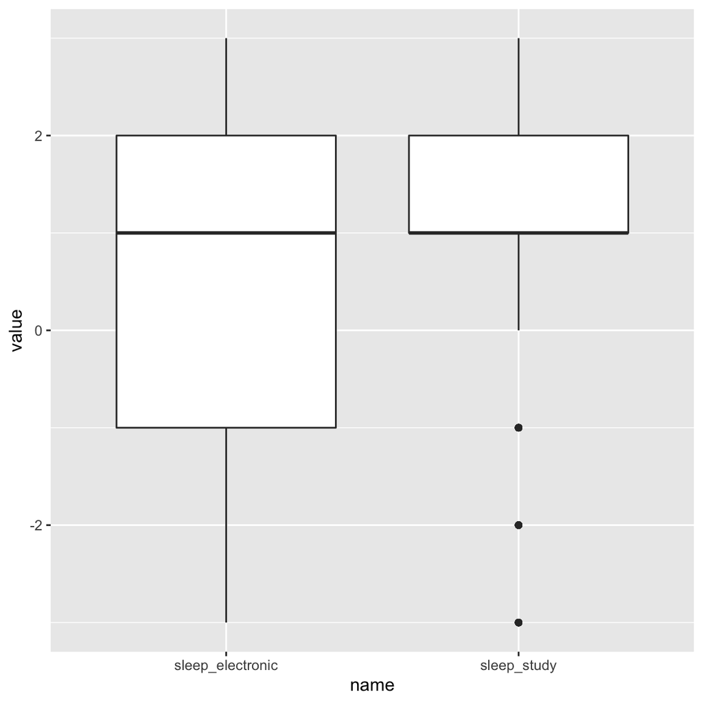

```r
# now we can pivot longer to make a plot
sleep.tidy %>%
  pivot_longer(c(sleep_study, sleep_electronic)) %>%
  ggplot(aes(name, value)) + geom_boxplot()
```

And make a summary score combining both questions

```r
sleep.tidy.withsumary <- sleep.tidy %>%
  # and create the summary score
  mutate(sleep_quality = sleep_study + sleep_electronic )

# check the result. it looks ok
sleep.tidy.withsumary %>% glimpse
```

```
Rows: 241
Columns: 13
$ uniqueid                                                                                    <chr> …
$ `Start time`                                                                                <dttm> …
$ `Completion time`                                                                           <dttm> …
$ `My sleep is affected by my study commitments`                                              <chr> …
$ `I achieve good quality sleep`                                                              <chr> …
$ `My electronic device usage negatively affects my sleep`                                    <chr> …
$ `Tiredness interferes with my concentration`                                                <chr> …
$ `My sleep is disturbed by external factors e.g. loud cars, housemates, lights, children...` <chr> …
$ `I often achieve eight hours of sleep`                                                      <chr> …
$ `I regularly stay up past 11pm`                                                             <chr> …
$ sleep_study                                                                                 <dbl> …
$ sleep_electronic                                                                            <dbl> …
$ sleep_quality                                                                               <dbl> …
```

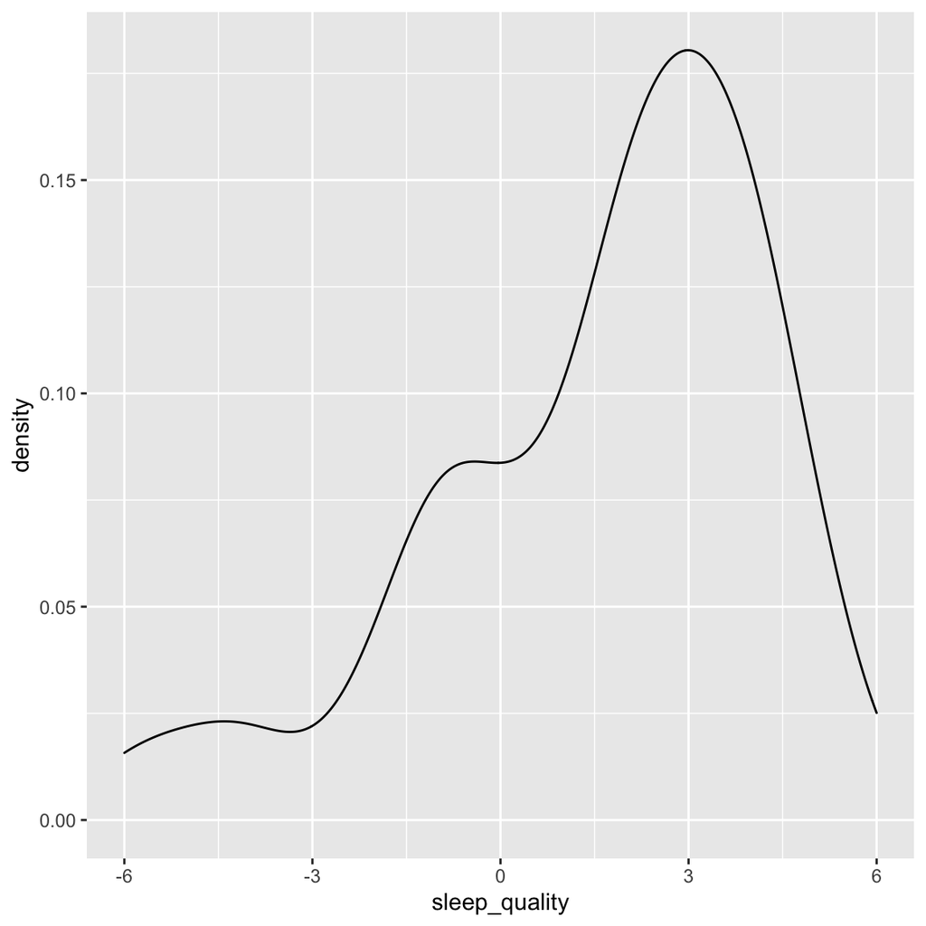

```r
# finally, make the requested density plot
# make the density plot
sleep.tidy.withsumary %>%
  ggplot(aes(sleep_quality)) +
  geom_density()
```

# Joining data

This is an optional extension section. It’s not needed for the assessment, but will be useful for those conducting studies using on-screen experiment software like OpenSesame.

Often we will have data from two different sources which must be combined. This section explains how to do that.

[video not shown]

Imagine we have two datasets like this, one containing identifying information:

| Identifier | Name |
| --- | --- |
| 123ABC | Ben |
| 456DEF | Helen |
| 678FGH | Esther |

And a second dataset containing sensitive questionnaire data:

| Identifier | Worst ever record purchase |
| --- | --- |
| 123ABC | Europe, the final countdown |
| 456DEF | Spice Girls Wannabe |
| 678FGH | One Direction - Night changes |

> Note that the `Identifier` column is common to both datasets.

We can use a new `tidyverse` function which joins these two datasets into a combined table:

```r
left_join(personal_data, research_data, by="Identifier")
```

```
# A tibble: 3 × 3
  Identifier Name   `Worst ever record purchase`
  <chr>      <chr>  <chr>
1 123ABC     Ben    Europe, the final countdown
2 456DEF     Helen  Spice Girls Wannabe
3 678FGH     Esther One Direction - Night changes
```

### Explanation of `left_join`

The `left_join` function takes two dataframes as input. We call the first input the ‘left hand side’, and the second input the ‘right hand side’.

Both left and right sides have to **share at least one column**. In this case it’s called `Identifier`.

When the left and right hand side match then `left_join` copies the extra columns *from the right hand side into the left hand side*.

**It returns a combined dataframe.**

Any extra rows in the right hand side which don’t match the left hand side are dropped. This might happen if we have research data for people we don’t have personal data for. There are [other functions like `full_join`](https://dplyr.tidyverse.org/reference/join.html#join-types) which do this a bit differently, but we don’t need them for now.

- Have a look at the `heroes_meta` and `heroes_personal` datasets, in `psydata`.
- Adapt the code for `left_join()` shown above to combine these datasets.
- Pipe the result of `left_join()` to `count()` to check how many rows are in the final dataset
- Does it matter which order you join the datasets in? Can you explain the number of rows in the resulting dataset?
- Save the combined dataset into a new csv file using `write_csv()`. Check you can find this in the RStudio files pane, and download a copy to be sure.

Do the join:

```r
left_join(heroes_meta, heroes_personal)
```

```
                         name         publisher gender               eye_color
1                     Giganta         DC Comics Female                   green
2               Black Goliath     Marvel Comics   <NA>                    <NA>
3                  Spider-Man     Marvel Comics      -                     red
4                  Spider-Man     Marvel Comics   Male                   brown
5                  Spider-Man     Marvel Comics   Male                   hazel
6              Superboy-Prime         DC Comics   Male                    blue
7               Lady Bullseye     Marvel Comics Female                       -
8                Black Canary         DC Comics Female                    blue
9                Black Canary         DC Comics Female                    blue
10            Black Lightning         DC Comics   Male                   brown
11                       X-23     Marvel Comics Female                   green
12                 Silverclaw     Marvel Comics Female                   brown
13              Hiro Nakamura      NBC - Heroes   Male                       -
14              Beta Ray Bill     Marvel Comics   <NA>                    <NA>
```

[output cut: 1365 more lines]

Count the rows:

```r
left_join(heroes_meta, heroes_personal) %>% count()
```

```
    n
1 689
```

```r
left_join(heroes_personal, heroes_meta) %>% count()
```

```
    n
1 691
```

We get slightly different numbers depending on which order we join the data in.

This is because `left_join` only keeps rows in the right hand dataset IF they have a match in the left hand side. If the number of rows in the left and right hand sides differ, you can get a different result.

Other functions like `inner_join` and `full_join` take different approaches. Type `?dplyr::inner_join` for an explanation.

This code would export a csv file to the same location as your `rmd` file:

```r
left_join(heroes_meta, heroes_personal) %>% rio::export('combined.csv')
```